# UzairAlladin_Assignment3

## Applied Data Science

#### Uzair Alladin (VIT Chennai) - 20BAI1062

### Assignment - 3

#### Problem Description:

House price prediction is a common problem in the real estate industry and involves predicting the selling price of a house based on various features and attributes. The problem is typically approached as a regression problem, where the target variable is the price of the house, and the features are various attributes of the house

The features used in house price prediction can include both quantitative and categorical variables, such as the number of bedrooms, house area, bedrooms, furnished, nearness to main road, and various amenities such as a garage and other factors that may influence the value of the property.

Accurate predictions can help agents and appraisers price homes correctly, while homeowners can use the predictions to set a reasonable asking price for their properties. Accurate house price prediction can also be useful for buyers who are looking to make informed decisions about purchasing a property and obtaining a fair price for their investment.

Attribute Information:  
Name - Description  
1- Price-Prices of the houses  
2- Area- Area of the houses  
3- Bedrooms- No of house bedrooms  
4- Bathrooms- No of bathrooms  
5- Stories- No of house stories  
6- Main Road- Weather connected to Main road  
7- Guestroom-Weather has a guest room  
8- Basement-Weather has a basement  
9- Hot water heating- Weather has a hot water heater  
10-Airconditioning-Weather has a air conditioner  
11-Parking- No of house parking  
12-Furnishing Status-Furnishing status of house

```python
import numpy as np
import pandas as pd
import matplotlib.pyplot as plt
import seaborn as sns
```

##### Question 1 - Load the Dataset

```python
df = pd.read_csv('Housing.csv')
df.head(10)
```

|  | price | area | bedrooms | bathrooms | stories | mainroad | guestroom | basement | hotwaterheating | airconditioning | parking | furnishingstatus |
| --- | --- | --- | --- | --- | --- | --- | --- | --- | --- | --- | --- | --- |
| 0 | 13300000 | 7420 | 4 | 2 | 3 | yes | no | no | no | yes | 2 | furnished |
| 1 | 12250000 | 8960 | 4 | 4 | 4 | yes | no | no | no | yes | 3 | furnished |
| 2 | 12250000 | 9960 | 3 | 2 | 2 | yes | no | yes | no | no | 2 | semi-furnished |
| 3 | 12215000 | 7500 | 4 | 2 | 2 | yes | no | yes | no | yes | 3 | furnished |
| 4 | 11410000 | 7420 | 4 | 1 | 2 | yes | yes | yes | no | yes | 2 | furnished |
| 5 | 10850000 | 7500 | 3 | 3 | 1 | yes | no | yes | no | yes | 2 | semi-furnished |
| 6 | 10150000 | 8580 | 4 | 3 | 4 | yes | no | no | no | yes | 2 | semi-furnished |
| 7 | 10150000 | 16200 | 5 | 3 | 2 | yes | no | no | no | no | 0 | unfurnished |
| 8 | 9870000 | 8100 | 4 | 1 | 2 | yes | yes | yes | no | yes | 2 | furnished |
| 9 | 9800000 | 5750 | 3 | 2 | 4 | yes | yes | no | no | yes | 1 | unfurnished |

##### Question 2 - Perform Below Visualizations

- Univariate Analysis
- Bi-Variate Analysis
- Multi-Variate Analysis

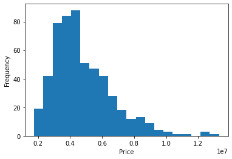

```python
#Considering the Price - Univariate Analysis
plt.hist(df['price'],bins=20)
plt.xlabel('Price')
plt.ylabel('Frequency')
plt.show()
```

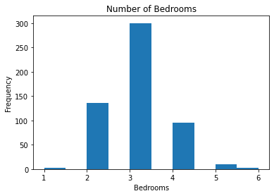

```python
#Considering the Number of Bedrooms - Univariate Analysis
plt.hist(df['bedrooms'],bins=10)
plt.xlabel('Bedrooms')
plt.ylabel('Frequency')
plt.title('Number of Bedrooms')
plt.show()
```

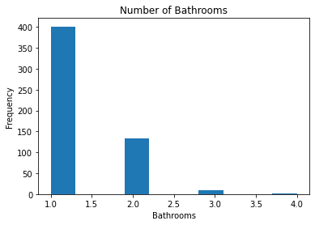

```python
#Considering the Number of Bathrooms - Univariate Analysis
plt.hist(df['bathrooms'],bins=10)
plt.xlabel('Bathrooms')
plt.ylabel('Frequency')
plt.title('Number of Bathrooms')
plt.show()
```

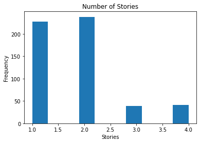

```python
#Considering the Number of Stories - Univariate Analysis
plt.hist(df['stories'],bins=10)
plt.xlabel('Stories')
plt.ylabel('Frequency')
plt.title('Number of Stories')
plt.show()
```

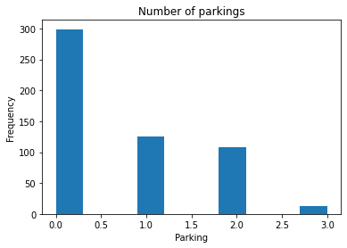

```python
#Considering the Number of Parking - Univariate Analysis
plt.hist(df['parking'],bins=10)
plt.xlabel('Parking')
plt.ylabel('Frequency')
plt.title('Number of parkings')
plt.show()
```

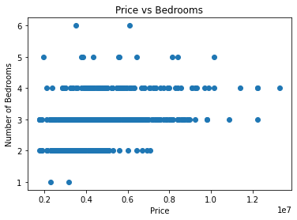

```python
#Considering the Price and Number of Bedrooms - Bivariate Analysis
plt.scatter(df['price'], df['bedrooms'])
plt.xlabel('Price')
plt.ylabel('Number of Bedrooms')
plt.title('Price vs Bedrooms')
plt.show()
```

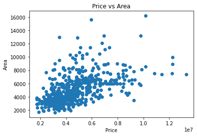

```python
#Considering the Area with the Price - Bivariate Analysis
plt.scatter(df['price'], df['area'])
plt.xlabel('Price')
plt.ylabel('Area')
plt.title('Price vs Area')
plt.show()
```

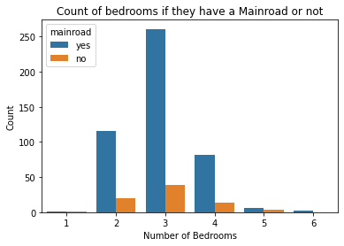

```python
#Bedrooms vs MainRoad - Bi-variate Analysis
sns.countplot(data=df, x=df['bedrooms'], hue=df['mainroad'])
plt.xlabel('Number of Bedrooms')
plt.ylabel('Count')
plt.title('Count of bedrooms if they have a Mainroad or not')
plt.show()
```

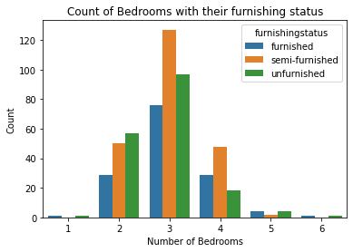

```python
#Bedrooms vs Furnishing Status - Bi-variate Analysis
sns.countplot(data=df, x=df['bedrooms'], hue=df['furnishingstatus'])
plt.xlabel('Number of Bedrooms')
plt.ylabel('Count')
plt.title('Count of Bedrooms with their furnishing status')
plt.show()
```

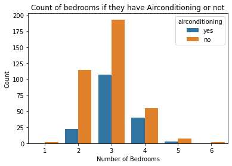

```python
#Bedrooms vs airconditioning - Bi-variate Analysis
sns.countplot(data=df, x=df['bedrooms'], hue=df['airconditioning'])
plt.xlabel('Number of Bedrooms')
plt.ylabel('Count')
plt.title('Count of bedrooms if they have Airconditioning or not')
plt.show()
```

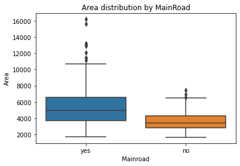

```python
#Area vs Mainroad - Bivariate Analysis
sns.boxplot(data=df, x='mainroad',y='area')
plt.xlabel('Mainroad')
plt.ylabel('Area')
plt.title('Area distribution by MainRoad')
plt.show()
```

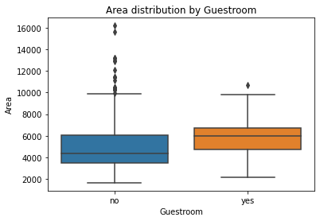

```python
#Area vs Guestroom - Bivariate Analysis
sns.boxplot(data=df, x='guestroom',y='area')
plt.xlabel('Guestroom')
plt.ylabel('Area')
plt.title('Area distribution by Guestroom')
plt.show()
```

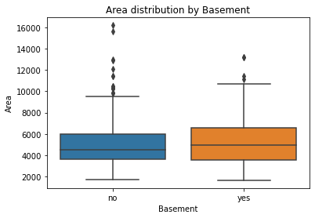

```python
#Area vs Basement - Bivariate Analysis
sns.boxplot(data=df, x='basement',y='area')
plt.xlabel('Basement')
plt.ylabel('Area')
plt.title('Area distribution by Basement')
plt.show()
```

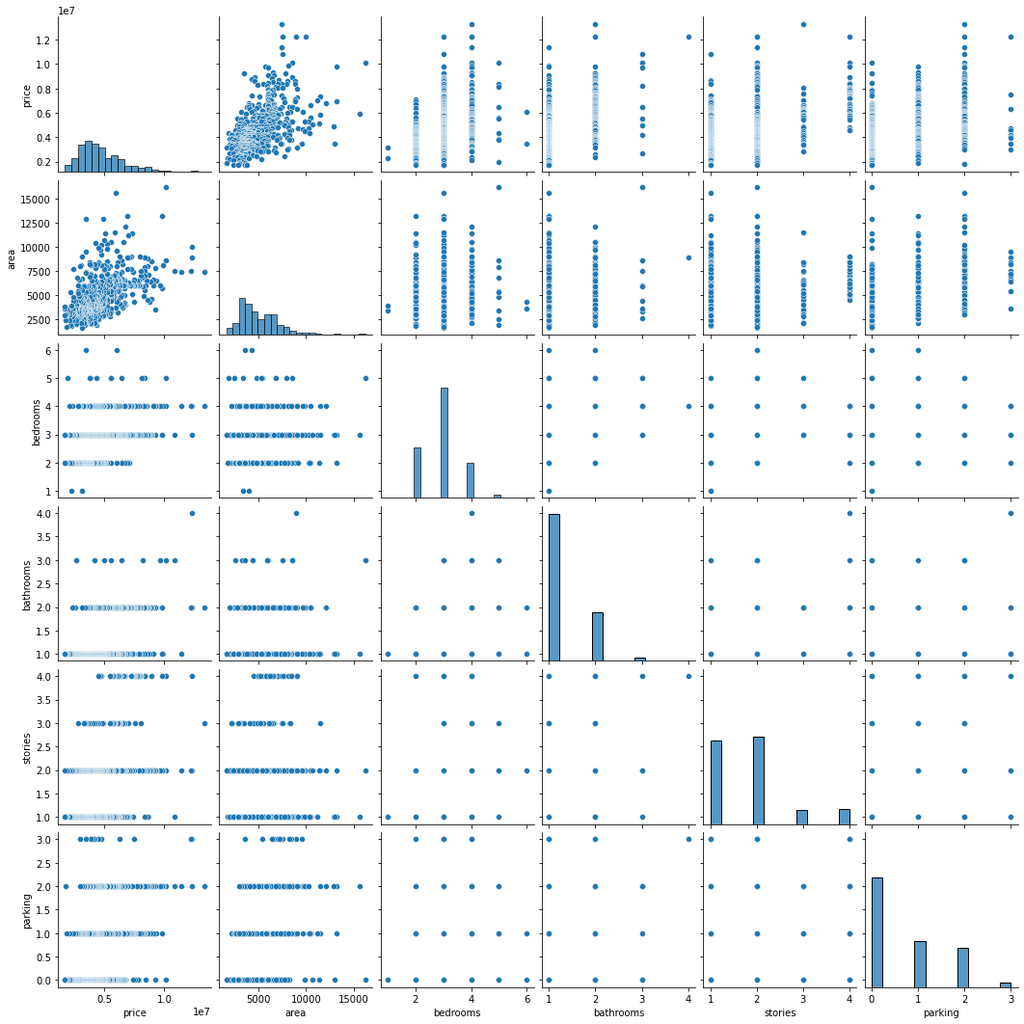

```python
sns.pairplot(data=df)
```

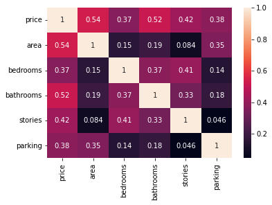

```python
sns.heatmap(df.corr(), annot=True)
plt.show()
```

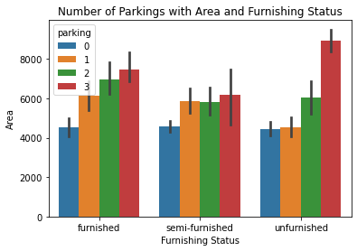

```python
sns.barplot(data=df, x='furnishingstatus', y='area', hue='parking')
plt.xlabel('Furnishing Status')
plt.ylabel('Area')
plt.title('Number of Parkings with Area and Furnishing Status')
plt.show()
```

##### Question 3 - Perform descriptive statistics on the dataset.

```python
df.describe()
```

|  | price | area | bedrooms | bathrooms | stories | parking |
| --- | --- | --- | --- | --- | --- | --- |
| count | 5.450000e+02 | 545.000000 | 545.000000 | 545.000000 | 545.000000 | 545.000000 |
| mean | 4.766729e+06 | 5150.541284 | 2.965138 | 1.286239 | 1.805505 | 0.693578 |
| std | 1.870440e+06 | 2170.141023 | 0.738064 | 0.502470 | 0.867492 | 0.861586 |
| min | 1.750000e+06 | 1650.000000 | 1.000000 | 1.000000 | 1.000000 | 0.000000 |
| 25% | 3.430000e+06 | 3600.000000 | 2.000000 | 1.000000 | 1.000000 | 0.000000 |
| 50% | 4.340000e+06 | 4600.000000 | 3.000000 | 1.000000 | 2.000000 | 0.000000 |
| 75% | 5.740000e+06 | 6360.000000 | 3.000000 | 2.000000 | 2.000000 | 1.000000 |
| max | 1.330000e+07 | 16200.000000 | 6.000000 | 4.000000 | 4.000000 | 3.000000 |

```python
df.isnull().sum()
```

```
price               0
area                0
bedrooms            0
bathrooms           0
stories             0
mainroad            0
guestroom           0
basement            0
hotwaterheating     0
airconditioning     0
parking             0
furnishingstatus    0
dtype: int64
```

```python
corr_matrix = df.corr()
corr_matrix
```

|  | price | area | bedrooms | bathrooms | stories | parking |
| --- | --- | --- | --- | --- | --- | --- |
| price | 1.000000 | 0.535997 | 0.366494 | 0.517545 | 0.420712 | 0.384394 |
| area | 0.535997 | 1.000000 | 0.151858 | 0.193820 | 0.083996 | 0.352980 |
| bedrooms | 0.366494 | 0.151858 | 1.000000 | 0.373930 | 0.408564 | 0.139270 |
| bathrooms | 0.517545 | 0.193820 | 0.373930 | 1.000000 | 0.326165 | 0.177496 |
| stories | 0.420712 | 0.083996 | 0.408564 | 0.326165 | 1.000000 | 0.045547 |
| parking | 0.384394 | 0.352980 | 0.139270 | 0.177496 | 0.045547 | 1.000000 |

##### Question 4 - Check for Missing values and deal with them.

```python
df.isnull().sum()
```

```
price               0
area                0
bedrooms            0
bathrooms           0
stories             0
mainroad            0
guestroom           0
basement            0
hotwaterheating     0
airconditioning     0
parking             0
furnishingstatus    0
dtype: int64
```

Therefore, they are no missing values in the dataset

##### Question 5 - Find the outliers and replace the outliers

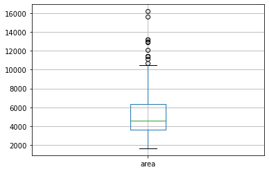

```python
df.boxplot(column = 'area')
```

```python
#Handling the Outliers of Area
area_median = df['area'].median()

#Calculating the upper and the lower threshold
area_upper_threshold = df['area'].quantile(0.75) + 1.5 * (df['area'].quantile(0.75) - df['area'].quantile(0.25))
area_lower_threshold = df['area'].quantile(0.25) - 1.5 * (df['area'].quantile(0.75) - df['area'].quantile(0.25))

#Changing the Outliers
df.loc[df['area'] > area_upper_threshold] = area_median
df.loc[df['area'] < area_lower_threshold] = area_median
```

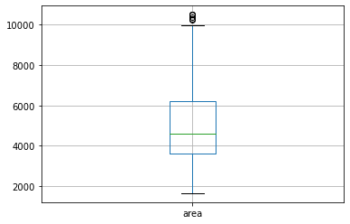

```python
df.boxplot(column = 'area')
```

##### Question 6 - Check for Categorical columns and perform encoding.

```python
print(df.dtypes)
```

```
price                int64
area                 int64
bedrooms             int64
bathrooms            int64
stories              int64
mainroad            object
guestroom           object
basement            object
hotwaterheating     object
airconditioning     object
parking              int64
furnishingstatus    object
dtype: object
```

```python
# #Replacing the yes and no columns:
# df['mainroad'] = df['mainroad'].replace({'yes' : 1, 'no' : 0})
# df['guestroom'] = df['guestroom'].replace({'yes' : 1, 'no' : 0})
# df['basement'] = df['basement'].replace({'yes' : 1, 'no' : 0})
# df['hotwaterheating'] = df['hotwaterheating'].replace({'yes' : 1, 'no' : 0})
# df['airconditioning'] = df['airconditioning'].replace({'yes' : 1, 'no' : 0})
# df.head(10)
```

```python
# furnish = pd.get_dummies(df['furnishingstatus'],drop_first=True)
# df.drop('furnishingstatus',axis=1,inplace=True)
# df = pd.concat([df,furnish],axis=1)
# df.head(50)
```

Tried the above commented codes for more accurate answer but the model did not improve

```python
df = pd.get_dummies(df)
df.head(25)
```

|  | price | area | bedrooms | bathrooms | stories | parking | mainroad_4600.0 | mainroad_no | mainroad_yes | guestroom_4600.0 | ... | hotwaterheating_4600.0 | hotwaterheating_no | hotwaterheating_yes | airconditioning_4600.0 | airconditioning_no | airconditioning_yes | furnishingstatus_4600.0 | furnishingstatus_furnished | furnishingstatus_semi-furnished | furnishingstatus_unfurnished |
| --- | --- | --- | --- | --- | --- | --- | --- | --- | --- | --- | --- | --- | --- | --- | --- | --- | --- | --- | --- | --- | --- |
| 0 | 13300000 | 7420 | 4 | 2 | 3 | 2 | 0 | 0 | 1 | 0 | ... | 0 | 1 | 0 | 0 | 0 | 1 | 0 | 1 | 0 | 0 |
| 1 | 12250000 | 8960 | 4 | 4 | 4 | 3 | 0 | 0 | 1 | 0 | ... | 0 | 1 | 0 | 0 | 0 | 1 | 0 | 1 | 0 | 0 |
| 2 | 12250000 | 9960 | 3 | 2 | 2 | 2 | 0 | 0 | 1 | 0 | ... | 0 | 1 | 0 | 0 | 1 | 0 | 0 | 0 | 1 | 0 |
| 3 | 12215000 | 7500 | 4 | 2 | 2 | 3 | 0 | 0 | 1 | 0 | ... | 0 | 1 | 0 | 0 | 0 | 1 | 0 | 1 | 0 | 0 |
| 4 | 11410000 | 7420 | 4 | 1 | 2 | 2 | 0 | 0 | 1 | 0 | ... | 0 | 1 | 0 | 0 | 0 | 1 | 0 | 1 | 0 | 0 |
| 5 | 10850000 | 7500 | 3 | 3 | 1 | 2 | 0 | 0 | 1 | 0 | ... | 0 | 1 | 0 | 0 | 0 | 1 | 0 | 0 | 1 | 0 |
| 6 | 10150000 | 8580 | 4 | 3 | 4 | 2 | 0 | 0 | 1 | 0 | ... | 0 | 1 | 0 | 0 | 0 | 1 | 0 | 0 | 1 | 0 |
| 7 | 4600 | 4600 | 4600 | 4600 | 4600 | 4600 | 1 | 0 | 0 | 1 | ... | 1 | 0 | 0 | 1 | 0 | 0 | 1 | 0 | 0 | 0 |
| 8 | 9870000 | 8100 | 4 | 1 | 2 | 2 | 0 | 0 | 1 | 0 | ... | 0 | 1 | 0 | 0 | 0 | 1 | 0 | 1 | 0 | 0 |
| 9 | 9800000 | 5750 | 3 | 2 | 4 | 1 | 0 | 0 | 1 | 0 | ... | 0 | 1 | 0 | 0 | 0 | 1 | 0 | 0 | 0 | 1 |
| 10 | 4600 | 4600 | 4600 | 4600 | 4600 | 4600 | 1 | 0 | 0 | 1 | ... | 1 | 0 | 0 | 1 | 0 | 0 | 1 | 0 | 0 | 0 |
| 11 | 9681000 | 6000 | 4 | 3 | 2 | 2 | 0 | 0 | 1 | 0 | ... | 0 | 0 | 1 | 0 | 1 | 0 | 0 | 0 | 1 | 0 |
| 12 | 9310000 | 6550 | 4 | 2 | 2 | 1 | 0 | 0 | 1 | 0 | ... | 0 | 1 | 0 | 0 | 0 | 1 | 0 | 0 | 1 | 0 |
| 13 | 9240000 | 3500 | 4 | 2 | 2 | 2 | 0 | 0 | 1 | 0 | ... | 0 | 0 | 1 | 0 | 1 | 0 | 0 | 1 | 0 | 0 |
| 14 | 9240000 | 7800 | 3 | 2 | 2 | 0 | 0 | 0 | 1 | 0 | ... | 0 | 1 | 0 | 0 | 1 | 0 | 0 | 0 | 1 | 0 |
| 15 | 9100000 | 6000 | 4 | 1 | 2 | 2 | 0 | 0 | 1 | 0 | ... | 0 | 1 | 0 | 0 | 1 | 0 | 0 | 0 | 1 | 0 |
| 16 | 9100000 | 6600 | 4 | 2 | 2 | 1 | 0 | 0 | 1 | 0 | ... | 0 | 1 | 0 | 0 | 0 | 1 | 0 | 0 | 0 | 1 |
| 17 | 8960000 | 8500 | 3 | 2 | 4 | 2 | 0 | 0 | 1 | 0 | ... | 0 | 1 | 0 | 0 | 0 | 1 | 0 | 1 | 0 | 0 |
| 18 | 8890000 | 4600 | 3 | 2 | 2 | 2 | 0 | 0 | 1 | 0 | ... | 0 | 1 | 0 | 0 | 0 | 1 | 0 | 1 | 0 | 0 |
| 19 | 8855000 | 6420 | 3 | 2 | 2 | 1 | 0 | 0 | 1 | 0 | ... | 0 | 1 | 0 | 0 | 0 | 1 | 0 | 0 | 1 | 0 |
| 20 | 8750000 | 4320 | 3 | 1 | 2 | 2 | 0 | 0 | 1 | 0 | ... | 0 | 0 | 1 | 0 | 1 | 0 | 0 | 0 | 1 | 0 |
| 21 | 8680000 | 7155 | 3 | 2 | 1 | 2 | 0 | 0 | 1 | 0 | ... | 0 | 1 | 0 | 0 | 0 | 1 | 0 | 0 | 0 | 1 |
| 22 | 8645000 | 8050 | 3 | 1 | 1 | 1 | 0 | 0 | 1 | 0 | ... | 0 | 1 | 0 | 0 | 0 | 1 | 0 | 1 | 0 | 0 |
| 23 | 8645000 | 4560 | 3 | 2 | 2 | 1 | 0 | 0 | 1 | 0 | ... | 0 | 1 | 0 | 0 | 0 | 1 | 0 | 1 | 0 | 0 |
| 24 | 8575000 | 8800 | 3 | 2 | 2 | 2 | 0 | 0 | 1 | 0 | ... | 0 | 1 | 0 | 0 | 0 | 1 | 0 | 1 | 0 | 0 |

25 rows × 25 columns

```python
df = df.drop([7,10])
df.head(25)
```

|  | price | area | bedrooms | bathrooms | stories | parking | mainroad_4600.0 | mainroad_no | mainroad_yes | guestroom_4600.0 | ... | hotwaterheating_4600.0 | hotwaterheating_no | hotwaterheating_yes | airconditioning_4600.0 | airconditioning_no | airconditioning_yes | furnishingstatus_4600.0 | furnishingstatus_furnished | furnishingstatus_semi-furnished | furnishingstatus_unfurnished |
| --- | --- | --- | --- | --- | --- | --- | --- | --- | --- | --- | --- | --- | --- | --- | --- | --- | --- | --- | --- | --- | --- |
| 0 | 13300000 | 7420 | 4 | 2 | 3 | 2 | 0 | 0 | 1 | 0 | ... | 0 | 1 | 0 | 0 | 0 | 1 | 0 | 1 | 0 | 0 |
| 1 | 12250000 | 8960 | 4 | 4 | 4 | 3 | 0 | 0 | 1 | 0 | ... | 0 | 1 | 0 | 0 | 0 | 1 | 0 | 1 | 0 | 0 |
| 2 | 12250000 | 9960 | 3 | 2 | 2 | 2 | 0 | 0 | 1 | 0 | ... | 0 | 1 | 0 | 0 | 1 | 0 | 0 | 0 | 1 | 0 |
| 3 | 12215000 | 7500 | 4 | 2 | 2 | 3 | 0 | 0 | 1 | 0 | ... | 0 | 1 | 0 | 0 | 0 | 1 | 0 | 1 | 0 | 0 |
| 4 | 11410000 | 7420 | 4 | 1 | 2 | 2 | 0 | 0 | 1 | 0 | ... | 0 | 1 | 0 | 0 | 0 | 1 | 0 | 1 | 0 | 0 |
| 5 | 10850000 | 7500 | 3 | 3 | 1 | 2 | 0 | 0 | 1 | 0 | ... | 0 | 1 | 0 | 0 | 0 | 1 | 0 | 0 | 1 | 0 |
| 6 | 10150000 | 8580 | 4 | 3 | 4 | 2 | 0 | 0 | 1 | 0 | ... | 0 | 1 | 0 | 0 | 0 | 1 | 0 | 0 | 1 | 0 |
| 8 | 9870000 | 8100 | 4 | 1 | 2 | 2 | 0 | 0 | 1 | 0 | ... | 0 | 1 | 0 | 0 | 0 | 1 | 0 | 1 | 0 | 0 |
| 9 | 9800000 | 5750 | 3 | 2 | 4 | 1 | 0 | 0 | 1 | 0 | ... | 0 | 1 | 0 | 0 | 0 | 1 | 0 | 0 | 0 | 1 |
| 11 | 9681000 | 6000 | 4 | 3 | 2 | 2 | 0 | 0 | 1 | 0 | ... | 0 | 0 | 1 | 0 | 1 | 0 | 0 | 0 | 1 | 0 |
| 12 | 9310000 | 6550 | 4 | 2 | 2 | 1 | 0 | 0 | 1 | 0 | ... | 0 | 1 | 0 | 0 | 0 | 1 | 0 | 0 | 1 | 0 |
| 13 | 9240000 | 3500 | 4 | 2 | 2 | 2 | 0 | 0 | 1 | 0 | ... | 0 | 0 | 1 | 0 | 1 | 0 | 0 | 1 | 0 | 0 |
| 14 | 9240000 | 7800 | 3 | 2 | 2 | 0 | 0 | 0 | 1 | 0 | ... | 0 | 1 | 0 | 0 | 1 | 0 | 0 | 0 | 1 | 0 |
| 15 | 9100000 | 6000 | 4 | 1 | 2 | 2 | 0 | 0 | 1 | 0 | ... | 0 | 1 | 0 | 0 | 1 | 0 | 0 | 0 | 1 | 0 |
| 16 | 9100000 | 6600 | 4 | 2 | 2 | 1 | 0 | 0 | 1 | 0 | ... | 0 | 1 | 0 | 0 | 0 | 1 | 0 | 0 | 0 | 1 |
| 17 | 8960000 | 8500 | 3 | 2 | 4 | 2 | 0 | 0 | 1 | 0 | ... | 0 | 1 | 0 | 0 | 0 | 1 | 0 | 1 | 0 | 0 |
| 18 | 8890000 | 4600 | 3 | 2 | 2 | 2 | 0 | 0 | 1 | 0 | ... | 0 | 1 | 0 | 0 | 0 | 1 | 0 | 1 | 0 | 0 |
| 19 | 8855000 | 6420 | 3 | 2 | 2 | 1 | 0 | 0 | 1 | 0 | ... | 0 | 1 | 0 | 0 | 0 | 1 | 0 | 0 | 1 | 0 |
| 20 | 8750000 | 4320 | 3 | 1 | 2 | 2 | 0 | 0 | 1 | 0 | ... | 0 | 0 | 1 | 0 | 1 | 0 | 0 | 0 | 1 | 0 |
| 21 | 8680000 | 7155 | 3 | 2 | 1 | 2 | 0 | 0 | 1 | 0 | ... | 0 | 1 | 0 | 0 | 0 | 1 | 0 | 0 | 0 | 1 |
| 22 | 8645000 | 8050 | 3 | 1 | 1 | 1 | 0 | 0 | 1 | 0 | ... | 0 | 1 | 0 | 0 | 0 | 1 | 0 | 1 | 0 | 0 |
| 23 | 8645000 | 4560 | 3 | 2 | 2 | 1 | 0 | 0 | 1 | 0 | ... | 0 | 1 | 0 | 0 | 0 | 1 | 0 | 1 | 0 | 0 |
| 24 | 8575000 | 8800 | 3 | 2 | 2 | 2 | 0 | 0 | 1 | 0 | ... | 0 | 1 | 0 | 0 | 0 | 1 | 0 | 1 | 0 | 0 |
| 25 | 8540000 | 6540 | 4 | 2 | 2 | 2 | 0 | 0 | 1 | 0 | ... | 0 | 1 | 0 | 0 | 0 | 1 | 0 | 1 | 0 | 0 |
| 26 | 8463000 | 6000 | 3 | 2 | 4 | 0 | 0 | 0 | 1 | 0 | ... | 0 | 1 | 0 | 0 | 0 | 1 | 0 | 0 | 1 | 0 |

25 rows × 25 columns

```python
print(df.dtypes)
```

```
price                              int64
area                               int64
bedrooms                           int64
bathrooms                          int64
stories                            int64
parking                            int64
mainroad_4600.0                    uint8
mainroad_no                        uint8
mainroad_yes                       uint8
guestroom_4600.0                   uint8
guestroom_no                       uint8
guestroom_yes                      uint8
basement_4600.0                    uint8
basement_no                        uint8
basement_yes                       uint8
hotwaterheating_4600.0             uint8
hotwaterheating_no                 uint8
hotwaterheating_yes                uint8
airconditioning_4600.0             uint8
airconditioning_no                 uint8
airconditioning_yes                uint8
furnishingstatus_4600.0            uint8
furnishingstatus_furnished         uint8
furnishingstatus_semi-furnished    uint8
furnishingstatus_unfurnished       uint8
dtype: object
```

##### Question 7 - Split the data into dependent and independent variables.

```python
X = df.drop('price',axis=1)
X
```

|  | area | bedrooms | bathrooms | stories | parking | mainroad_4600.0 | mainroad_no | mainroad_yes | guestroom_4600.0 | guestroom_no | ... | hotwaterheating_4600.0 | hotwaterheating_no | hotwaterheating_yes | airconditioning_4600.0 | airconditioning_no | airconditioning_yes | furnishingstatus_4600.0 | furnishingstatus_furnished | furnishingstatus_semi-furnished | furnishingstatus_unfurnished |
| --- | --- | --- | --- | --- | --- | --- | --- | --- | --- | --- | --- | --- | --- | --- | --- | --- | --- | --- | --- | --- | --- |
| 0 | 7420 | 4 | 2 | 3 | 2 | 0 | 0 | 1 | 0 | 1 | ... | 0 | 1 | 0 | 0 | 0 | 1 | 0 | 1 | 0 | 0 |
| 1 | 8960 | 4 | 4 | 4 | 3 | 0 | 0 | 1 | 0 | 1 | ... | 0 | 1 | 0 | 0 | 0 | 1 | 0 | 1 | 0 | 0 |
| 2 | 9960 | 3 | 2 | 2 | 2 | 0 | 0 | 1 | 0 | 1 | ... | 0 | 1 | 0 | 0 | 1 | 0 | 0 | 0 | 1 | 0 |
| 3 | 7500 | 4 | 2 | 2 | 3 | 0 | 0 | 1 | 0 | 1 | ... | 0 | 1 | 0 | 0 | 0 | 1 | 0 | 1 | 0 | 0 |
| 4 | 7420 | 4 | 1 | 2 | 2 | 0 | 0 | 1 | 0 | 0 | ... | 0 | 1 | 0 | 0 | 0 | 1 | 0 | 1 | 0 | 0 |
| ... | ... | ... | ... | ... | ... | ... | ... | ... | ... | ... | ... | ... | ... | ... | ... | ... | ... | ... | ... | ... | ... |
| 540 | 3000 | 2 | 1 | 1 | 2 | 0 | 0 | 1 | 0 | 1 | ... | 0 | 1 | 0 | 0 | 1 | 0 | 0 | 0 | 0 | 1 |
| 541 | 2400 | 3 | 1 | 1 | 0 | 0 | 1 | 0 | 0 | 1 | ... | 0 | 1 | 0 | 0 | 1 | 0 | 0 | 0 | 1 | 0 |
| 542 | 3620 | 2 | 1 | 1 | 0 | 0 | 0 | 1 | 0 | 1 | ... | 0 | 1 | 0 | 0 | 1 | 0 | 0 | 0 | 0 | 1 |
| 543 | 2910 | 3 | 1 | 1 | 0 | 0 | 1 | 0 | 0 | 1 | ... | 0 | 1 | 0 | 0 | 1 | 0 | 0 | 1 | 0 | 0 |
| 544 | 3850 | 3 | 1 | 2 | 0 | 0 | 0 | 1 | 0 | 1 | ... | 0 | 1 | 0 | 0 | 1 | 0 | 0 | 0 | 0 | 1 |

543 rows × 24 columns

```python
y = df['price']
y
```

```
0      13300000
1      12250000
2      12250000
3      12215000
4      11410000
         ...
540     1820000
541     1767150
542     1750000
543     1750000
544     1750000
Name: price, Length: 543, dtype: int64
```

##### Question 8 - Scale the independent variables

```python
from sklearn.preprocessing import StandardScaler
scale = StandardScaler()
normalise = scale.fit_transform(X)
X = pd.DataFrame(normalise, columns=X.columns)
X.head(20)
```

|  | area | bedrooms | bathrooms | stories | parking | mainroad_4600.0 | mainroad_no | mainroad_yes | guestroom_4600.0 | guestroom_no | ... | hotwaterheating_4600.0 | hotwaterheating_no | hotwaterheating_yes | airconditioning_4600.0 | airconditioning_no | airconditioning_yes | furnishingstatus_4600.0 | furnishingstatus_furnished | furnishingstatus_semi-furnished | furnishingstatus_unfurnished |
| --- | --- | --- | --- | --- | --- | --- | --- | --- | --- | --- | --- | --- | --- | --- | --- | --- | --- | --- | --- | --- | --- |
| 0 | 1.331610 | -0.135292 | -0.135820 | -0.135046 | -0.134846 | -0.136973 | -0.406492 | 0.436795 | -0.136973 | 0.492507 | ... | -0.136973 | 0.258452 | -0.215041 | -0.136973 | -1.426015 | 1.487622 | -0.136973 | 1.747066 | -0.834790 | -0.692506 |
| 1 | 2.169892 | -0.135292 | -0.132586 | -0.133429 | -0.133229 | -0.136973 | -0.406492 | 0.436795 | -0.136973 | 0.492507 | ... | -0.136973 | 0.258452 | -0.215041 | -0.136973 | -1.426015 | 1.487622 | -0.136973 | 1.747066 | -0.834790 | -0.692506 |
| 2 | 2.714231 | -0.136910 | -0.135820 | -0.136664 | -0.134846 | -0.136973 | -0.406492 | 0.436795 | -0.136973 | 0.492507 | ... | -0.136973 | 0.258452 | -0.215041 | -0.136973 | 0.701255 | -0.672214 | -0.136973 | -0.572388 | 1.197905 | -0.692506 |
| 3 | 1.375157 | -0.135292 | -0.135820 | -0.136664 | -0.133229 | -0.136973 | -0.406492 | 0.436795 | -0.136973 | 0.492507 | ... | -0.136973 | 0.258452 | -0.215041 | -0.136973 | -1.426015 | 1.487622 | -0.136973 | 1.747066 | -0.834790 | -0.692506 |
| 4 | 1.331610 | -0.135292 | -0.137438 | -0.136664 | -0.134846 | -0.136973 | -0.406492 | 0.436795 | -0.136973 | -2.030429 | ... | -0.136973 | 0.258452 | -0.215041 | -0.136973 | -1.426015 | 1.487622 | -0.136973 | 1.747066 | -0.834790 | -0.692506 |
| 5 | 1.375157 | -0.136910 | -0.134203 | -0.138281 | -0.134846 | -0.136973 | -0.406492 | 0.436795 | -0.136973 | 0.492507 | ... | -0.136973 | 0.258452 | -0.215041 | -0.136973 | -1.426015 | 1.487622 | -0.136973 | -0.572388 | 1.197905 | -0.692506 |
| 6 | 1.963043 | -0.135292 | -0.134203 | -0.133429 | -0.134846 | -0.136973 | -0.406492 | 0.436795 | -0.136973 | 0.492507 | ... | -0.136973 | 0.258452 | -0.215041 | -0.136973 | -1.426015 | 1.487622 | -0.136973 | -0.572388 | 1.197905 | -0.692506 |
| 7 | 1.701760 | -0.135292 | -0.137438 | -0.136664 | -0.134846 | -0.136973 | -0.406492 | 0.436795 | -0.136973 | -2.030429 | ... | -0.136973 | 0.258452 | -0.215041 | -0.136973 | -1.426015 | 1.487622 | -0.136973 | 1.747066 | -0.834790 | -0.692506 |
| 8 | 0.422563 | -0.136910 | -0.135820 | -0.133429 | -0.136464 | -0.136973 | -0.406492 | 0.436795 | -0.136973 | -2.030429 | ... | -0.136973 | 0.258452 | -0.215041 | -0.136973 | -1.426015 | 1.487622 | -0.136973 | -0.572388 | -0.834790 | 1.444032 |
| 9 | 0.558648 | -0.135292 | -0.134203 | -0.136664 | -0.134846 | -0.136973 | -0.406492 | 0.436795 | -0.136973 | -2.030429 | ... | -0.136973 | -3.869184 | 4.650269 | -0.136973 | 0.701255 | -0.672214 | -0.136973 | -0.572388 | 1.197905 | -0.692506 |
| 10 | 0.858035 | -0.135292 | -0.135820 | -0.136664 | -0.136464 | -0.136973 | -0.406492 | 0.436795 | -0.136973 | 0.492507 | ... | -0.136973 | 0.258452 | -0.215041 | -0.136973 | -1.426015 | 1.487622 | -0.136973 | -0.572388 | 1.197905 | -0.692506 |
| 11 | -0.802199 | -0.135292 | -0.135820 | -0.136664 | -0.134846 | -0.136973 | -0.406492 | 0.436795 | -0.136973 | 0.492507 | ... | -0.136973 | -3.869184 | 4.650269 | -0.136973 | 0.701255 | -0.672214 | -0.136973 | 1.747066 | -0.834790 | -0.692506 |
| 12 | 1.538458 | -0.136910 | -0.135820 | -0.136664 | -0.138081 | -0.136973 | -0.406492 | 0.436795 | -0.136973 | 0.492507 | ... | -0.136973 | 0.258452 | -0.215041 | -0.136973 | 0.701255 | -0.672214 | -0.136973 | -0.572388 | 1.197905 | -0.692506 |
| 13 | 0.558648 | -0.135292 | -0.137438 | -0.136664 | -0.134846 | -0.136973 | -0.406492 | 0.436795 | -0.136973 | 0.492507 | ... | -0.136973 | 0.258452 | -0.215041 | -0.136973 | 0.701255 | -0.672214 | -0.136973 | -0.572388 | 1.197905 | -0.692506 |
| 14 | 0.885252 | -0.135292 | -0.135820 | -0.136664 | -0.136464 | -0.136973 | -0.406492 | 0.436795 | -0.136973 | -2.030429 | ... | -0.136973 | 0.258452 | -0.215041 | -0.136973 | -1.426015 | 1.487622 | -0.136973 | -0.572388 | -0.834790 | 1.444032 |
| 15 | 1.919496 | -0.136910 | -0.135820 | -0.133429 | -0.134846 | -0.136973 | -0.406492 | 0.436795 | -0.136973 | 0.492507 | ... | -0.136973 | 0.258452 | -0.215041 | -0.136973 | -1.426015 | 1.487622 | -0.136973 | 1.747066 | -0.834790 | -0.692506 |
| 16 | -0.203426 | -0.136910 | -0.135820 | -0.136664 | -0.134846 | -0.136973 | -0.406492 | 0.436795 | -0.136973 | -2.030429 | ... | -0.136973 | 0.258452 | -0.215041 | -0.136973 | -1.426015 | 1.487622 | -0.136973 | 1.747066 | -0.834790 | -0.692506 |
| 17 | 0.787271 | -0.136910 | -0.135820 | -0.136664 | -0.136464 | -0.136973 | -0.406492 | 0.436795 | -0.136973 | 0.492507 | ... | -0.136973 | 0.258452 | -0.215041 | -0.136973 | -1.426015 | 1.487622 | -0.136973 | -0.572388 | 1.197905 | -0.692506 |
| 18 | -0.355841 | -0.136910 | -0.137438 | -0.136664 | -0.134846 | -0.136973 | -0.406492 | 0.436795 | -0.136973 | 0.492507 | ... | -0.136973 | -3.869184 | 4.650269 | -0.136973 | 0.701255 | -0.672214 | -0.136973 | -0.572388 | 1.197905 | -0.692506 |
| 19 | 1.187360 | -0.136910 | -0.135820 | -0.138281 | -0.134846 | -0.136973 | -0.406492 | 0.436795 | -0.136973 | -2.030429 | ... | -0.136973 | 0.258452 | -0.215041 | -0.136973 | -1.426015 | 1.487622 | -0.136973 | -0.572388 | -0.834790 | 1.444032 |

20 rows × 24 columns

```python
# from sklearn.preprocessing import MinMaxScaler
# scale = MinMaxScaler()
# normalise = scale.fit_transform(X)
# X = pd.DataFrame(normalise, columns=X.columns)
# X.head(20)
```

##### Question 9 - Split the data into training and testing

```python
from sklearn.model_selection import train_test_split
X_train,X_test,y_train,y_test = train_test_split(X,y,test_size=0.2)
```

```python
X_train.info()
```

```
<class 'pandas.core.frame.DataFrame'>
Int64Index: 434 entries, 516 to 164
Data columns (total 24 columns):
 #   Column                           Non-Null Count  Dtype
---  ------                           --------------  -----
 0   area                             434 non-null    float64
 1   bedrooms                         434 non-null    float64
 2   bathrooms                        434 non-null    float64
 3   stories                          434 non-null    float64
 4   parking                          434 non-null    float64
 5   mainroad_4600.0                  434 non-null    float64
 6   mainroad_no                      434 non-null    float64
 7   mainroad_yes                     434 non-null    float64
 8   guestroom_4600.0                 434 non-null    float64
 9   guestroom_no                     434 non-null    float64
```

[output cut: 16 more lines]

```python
X_test.info()
```

```
<class 'pandas.core.frame.DataFrame'>
Int64Index: 109 entries, 246 to 155
Data columns (total 24 columns):
 #   Column                           Non-Null Count  Dtype
---  ------                           --------------  -----
 0   area                             109 non-null    float64
 1   bedrooms                         109 non-null    float64
 2   bathrooms                        109 non-null    float64
 3   stories                          109 non-null    float64
 4   parking                          109 non-null    float64
 5   mainroad_4600.0                  109 non-null    float64
 6   mainroad_no                      109 non-null    float64
 7   mainroad_yes                     109 non-null    float64
 8   guestroom_4600.0                 109 non-null    float64
 9   guestroom_no                     109 non-null    float64
```

[output cut: 16 more lines]

##### Question 10 - Build the Model

```python
from sklearn.linear_model import LinearRegression
linmodel = LinearRegression()
```

##### Question 11 - Train the Model

```python
linmodel.fit(X_train,y_train)
```

```
LinearRegression()
```

```python
print(linmodel.intercept_)
```

```
4635039.719827978
```

```python
coeff_df = pd.DataFrame(data=linmodel.coef_,index=X.columns,columns=['Coefficient'])
coeff_df
```

|  | Coefficient |
| --- | --- |
| area | 5.195040e+05 |
| bedrooms | 1.221501e+08 |
| bathrooms | 5.361496e+08 |
| stories | 2.709262e+08 |
| parking | 1.016106e+08 |
| mainroad_4600.0 | -1.607107e+08 |
| mainroad_no | 2.931450e+07 |
| mainroad_yes | 3.102781e+07 |
| guestroom_4600.0 | -1.607107e+08 |
| guestroom_no | 2.821728e+07 |
| guestroom_yes | 2.732245e+07 |
| basement_4600.0 | -1.607107e+08 |
| basement_no | 2.267019e+07 |
| basement_yes | 2.258873e+07 |
| hotwaterheating_4600.0 | -1.607107e+08 |
| hotwaterheating_no | 5.177697e+07 |
| hotwaterheating_yes | 4.409783e+07 |
| airconditioning_4600.0 | -1.607107e+08 |
| airconditioning_no | 2.312840e+07 |
| airconditioning_yes | 2.318661e+07 |
| furnishingstatus_4600.0 | -1.607107e+08 |
| furnishingstatus_furnished | 1.447397e+07 |
| furnishingstatus_semi-furnished | 1.648068e+07 |
| furnishingstatus_unfurnished | 1.551052e+07 |

##### Question 12 - Test the Model

```python
predictions = linmodel.predict(X_test)
predictions
```

```
array([4.91010394e+06, 4.12460286e+06, 8.72323561e+06, 6.81777975e+06,
       3.07074588e+06, 4.34473346e+06, 3.88463488e+06, 4.19537875e+06,
       3.14512682e+06, 3.46715368e+06, 4.29797708e+06, 7.71495879e+06,
       2.85915581e+06, 4.60110031e+06, 4.51996433e+06, 4.10565555e+06,
       5.33071979e+06, 4.12412114e+06, 3.09091778e+06, 2.59531350e+06,
       5.37384705e+06, 4.06609777e+06, 3.06125685e+06, 5.19247557e+06,
       4.48977907e+06, 4.34195960e+06, 3.83324310e+06, 4.63072272e+06,
       5.07042324e+06, 3.97141653e+06, 7.39686386e+06, 4.37474892e+06,
       1.03459049e+07, 5.43061371e+06, 3.20050651e+06, 3.94902424e+06,
       5.07971348e+06, 2.15193035e+06, 4.23041452e+06, 5.64450800e+06,
       4.46025836e+06, 6.24400573e+06, 4.05658542e+06, 3.80960534e+06,
       4.22631607e+06, 5.75794603e+06, 6.59456329e+06, 3.82163096e+06,
       5.33611665e+06, 3.54167251e+06, 6.63183995e+06, 5.89955934e+06,
       3.62737199e+06, 3.46827501e+06, 3.67333073e+06, 3.16138632e+06,
       4.24972988e+06, 7.11549148e+06, 5.48929519e+06, 4.86634886e+06,
       5.47388355e+06, 3.43356886e+06, 7.01252414e+06, 5.04335900e+06,
       5.07471520e+06, 2.55128082e+06, 5.16186262e+06, 3.54103099e+06,
       8.27847016e+06, 5.18580271e+06, 3.39235866e+06, 4.14764782e+06,
       4.33304467e+06, 4.40347159e+06, 5.00014163e+06, 6.54153987e+06,
       6.55100466e+06, 3.09619481e+06, 4.66866590e+06, 4.04846139e+06,
       5.49057516e+06, 4.70487559e+06, 5.26690358e+06, 3.13812127e+06,
       3.92746507e+06, 5.24417759e+06, 2.81264672e+06, 4.27508229e+06,
       3.64699599e+06, 3.50296639e+06, 4.60000000e+03, 8.45863343e+06,
       6.13198446e+06, 3.87984398e+06, 6.08780009e+06, 5.76617991e+06,
       5.43313845e+06, 4.41040748e+06, 3.80245768e+06, 7.71948691e+06,
       3.36836551e+06, 5.45447282e+06, 5.26605453e+06, 4.10072467e+06,
       3.68872139e+06, 4.44305375e+06, 6.51983743e+06, 6.38256473e+06,
       5.06040306e+06])
```

##### Question 13 - Measure the performance using Metrics.

```python
from sklearn import metrics
print('Mean Absolute Error (MAE): ', metrics.mean_absolute_error(y_test,predictions))
print('Mean Squared Error (MSE): ', metrics.mean_squared_error(y_test,predictions))
print('Root Mean Squared Error (RMSE): ', np.sqrt(metrics.mean_squared_error(y_test,predictions)))
```

```
Mean Absolute Error (MAE):  774141.7083120885
Mean Squared Error (MSE):  1164438062987.9395
Root Mean Squared Error (RMSE):  1079091.3135541123
```